# part2

Lulu

7/3/2020

## Project Descriptions

1. Load the ToothGrowth data and perform some basic exploratory data analyses
2. Provide a basic summary of the data.
3. Use confidence intervals and/or hypothesis tests to compare tooth growth by supp and dose.
4. State your conclusions and the assumptions needed for your conclusions.

## Point 1

1. Provide a basic summary of the data.

```
## 'data.frame':    60 obs. of  3 variables:
##  $ len : num  4.2 11.5 7.3 5.8 6.4 10 11.2 11.2 5.2 7 ...
##  $ supp: Factor w/ 2 levels "OJ","VC": 2 2 2 2 2 2 2 2 2 2 ...
##  $ dose: num  0.5 0.5 0.5 0.5 0.5 0.5 0.5 0.5 0.5 0.5 ...
```

ToothGrowth is a “data.frame” containing 60 observations of 3 variables: “len”, numeric; “supp”, factor; “dose”, numeric. There are two supplements: VC and OJ. Each one contains three doses at 0.5, 1.0, and 2.0. There are 10 observations for each supp at each dose.

```
## # A tibble: 6 x 3
## # Groups:   supp [2]
##   supp   dose `mean(len)`
##   <chr> <dbl>       <dbl>
## 1 OJ      0.5       13.2
## 2 OJ      1         22.7
## 3 OJ      2         26.1
## 4 VC      0.5        7.98
## 5 VC      1         16.8
## 6 VC      2         26.1
```

```
## # A tibble: 6 x 3
## # Groups:   supp [2]
##   supp   dose `sd(len)`
##   <chr> <dbl>     <dbl>
## 1 OJ      0.5      4.46
## 2 OJ      1        3.91
## 3 OJ      2        2.66
## 4 VC      0.5      2.75
## 5 VC      1        2.52
## 6 VC      2        4.80
```

As shown in the table, higher doses of VC or OJ induced more tooth growth. Maximum average of tooth growth 26.14 was observed at VC dose of 2.0.

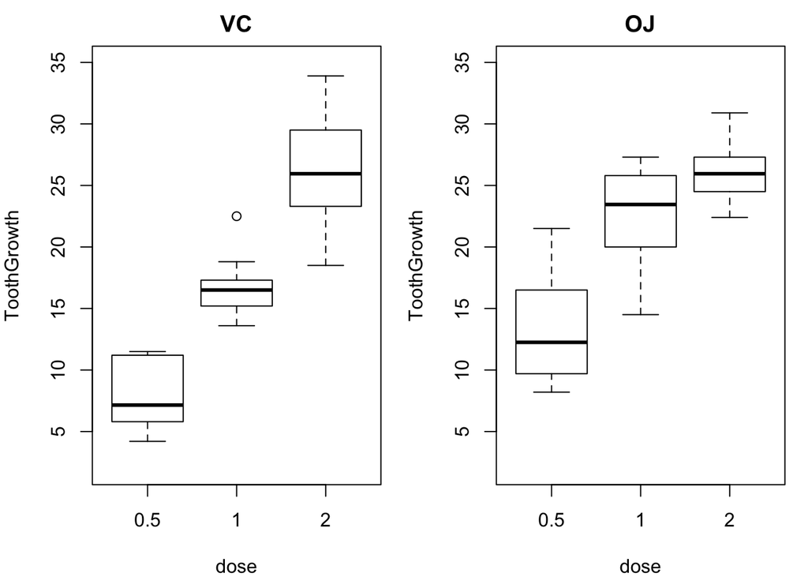

## Point 3

Use confidence intervals and/or hypothesis tests to compare tooth growth by supp and dose.

1. Compare tooth growth associated with different doses for same supplement.

1.1 Run t test to compare vc_half and vc_1. Hypothesis H0: same tooth growth at vc_1 and vc_half; Ha: more tooth growth at vc_1 compared to vc_half. Assumes same variance in two groups.

```r
t.test(vc_1$len-vc_half$len, alternative="greater")
```

```
##
##  One Sample t-test
##
## data:  vc_1$len - vc_half$len
## t = 6.1364, df = 9, p-value = 8.576e-05
## alternative hypothesis: true mean is greater than 0
## 95 percent confidence interval:
##  6.16418     Inf
## sample estimates:
## mean of x
##      8.79
```

One sample t-test results show the 95 percent confidence interval of vc_1$len-vc_half$len is 6.16418 to Inf. Therefore, more tooth growth is associated with vc_1 compared to vc_half.

1.2 Run t test to compare vc_2 and vc_1. Hypothesis H0: same tooth growth at vc_2 and vc_1; Ha: more tooth growth at vc_2 compared to vc_1. Assumes same variance in two groups.

```r
t.test(vc_2$len-vc_1$len, alternative="greater")
```

```
##
##  One Sample t-test
##
## data:  vc_2$len - vc_1$len
## t = 5.346, df = 9, p-value = 0.0002324
## alternative hypothesis: true mean is greater than 0
## 95 percent confidence interval:
##  6.157075      Inf
## sample estimates:
## mean of x
##      9.37
```

One sample t-test results show the 95 percent confidence interval of vc_2$len-vc_1$len is 6.157075 to Inf. Therefore, more tooth growth is associated with vc_2 compared to vc_1.

1.3 Run t test to compare oj_half and oj_1. Hypothesis H0: same tooth growth at oj_1 and oj_half; Ha: more tooth growth at oj_1 compared to oj_half. Assumes same variance in two groups.

```r
t.test(oj_1$len-oj_half$len, alternative="greater")
```

```
##
##  One Sample t-test
##
## data:  oj_1$len - oj_half$len
## t = 4.1635, df = 9, p-value = 0.001218
## alternative hypothesis: true mean is greater than 0
## 95 percent confidence interval:
##  5.300497      Inf
## sample estimates:
## mean of x
##      9.47
```

One sample t-test results show the 95 percent confidence interval of oj_1$len-oj_half$len is 5.300497 to Inf. Therefore, more tooth growth is associated with oj_1 compared to oj_half.

1.4 Run t test to compare oj_2 and oj_1. Hypothesis H0: same tooth growth at oj_2 and oj_1; Ha: more tooth growth at oj_2 compared to oj_1. Assumes same variance in two groups.

```r
t.test(oj_2$len-oj_1$len, alternative="greater")
```

```
##
##  One Sample t-test
##
## data:  oj_2$len - oj_1$len
## t = 1.9435, df = 9, p-value = 0.04192
## alternative hypothesis: true mean is greater than 0
## 95 percent confidence interval:
##  0.1908169       Inf
## sample estimates:
## mean of x
##      3.36
```

One sample t-test results show the 95 percent confidence interval of oj_2$len-oj_1$len is 0.1908169 to Inf. Therefore, more tooth growth is associated with oj_2 compared to oj_1.

Conclusion: more tooth growth is associated with higher doses for the same supplement.

2. Compare tooth growth associated with different supplement at the same doses.

2.1 Run t test to compare vc_half and oj_half. Hypothesis H0: same tooth growth at vc_half and oj_half; Ha: more tooth growth at oj_half compared to vc_half. Assumes same variance in two groups.

```r
t.test(oj_half$len-vc_half$len, alternative="greater")
```

```
##
##  One Sample t-test
##
## data:  oj_half$len - vc_half$len
## t = 2.9791, df = 9, p-value = 0.007736
## alternative hypothesis: true mean is greater than 0
## 95 percent confidence interval:
##  2.019552      Inf
## sample estimates:
## mean of x
##      5.25
```

One sample t-test results show the 95 percent confidence interval of oj_half$len-vc_half$len is 2.019552 to Inf. Therefore, more tooth growth is ssociated with oj_half compared to vc_half.

2.2 Run t test to compare vc_1 and oj_1. Hypothesis H0: same tooth growth at vc_1 and oj_1; Ha: more tooth growth at oj_1 compared to vc_1. Assumes same variance in two groups.

```r
t.test(oj_1$len-vc_1$len, alternative="greater")
```

```
##
##  One Sample t-test
##
## data:  oj_1$len - vc_1$len
## t = 3.3721, df = 9, p-value = 0.004115
## alternative hypothesis: true mean is greater than 0
## 95 percent confidence interval:
##  2.706401      Inf
## sample estimates:
## mean of x
##      5.93
```

One sample t-test results show the 95 percent confidence interval of oj_1$len-vc_1$len is 2.706401 to Inf. Therefore, more tooth growth is associated with oj_1 compared to vc_1.

3.3 Run t test to compare vc_2 and oj_2. Hypothesis H0: same tooth growth at vc_2 and oj_2; Ha: different tooth growth at vc_2 compared to oj_2. Assumes same variance in two groups.

```r
# Assumes same variance in two groups
t.test(vc_2$len-oj_2$len, alternative="two.sided")
```

```
##
##  One Sample t-test
##
## data:  vc_2$len - oj_2$len
## t = 0.042592, df = 9, p-value = 0.967
## alternative hypothesis: true mean is not equal to 0
## 95 percent confidence interval:
##  -4.168976  4.328976
## sample estimates:
## mean of x
##      0.08
```

One sample t-test results show the 95 percent confidence interval of vc_2$len-oj_2$len is -4.168976 to 4.328976. Therefore, accepting null hopothesis that same tooth growth at vc_2 and oj_2.